# Team 16 Tier-3 single-model forecast

Silicon Sample Benchmark

This report documents the locked **Claude Opus 4.6** secondary submission from team 16. It contains 208 average treatment effect (ATE) forecasts: one for each of 16 interventions crossed with 13 outcomes.

> **What is an ATE?** Here, an ATE is the predicted average difference between people assigned to an intervention and people assigned to the neutral control. Positive and negative values indicate the direction of that difference; the units are the original units of each outcome.

# 1. Submitted method

The model received the intervention, control material, outcome definitions, and native response scales. Two fixed, substantively equivalent prompts independently requested all 13 signed ATEs for every intervention. The submitted value for each cell is the median of those two prompt forecasts. There was no calibration, shrinkage, clipping, or manual editing.

| Item | Value |
| --- | --- |
| Entry | secondary-2 |
| Model | Claude Opus 4.6 |
| Prompt variants | 2 |
| Completions per intervention-prompt | 1 |
| Forecast cells | 208 |
| Aggregation | Median across prompts |

# 2. Submitted forecast map

The heatmap is the complete submitted forecast. Because outcomes use different native scales, color intensity should be compared primarily within an outcome column rather than across columns.

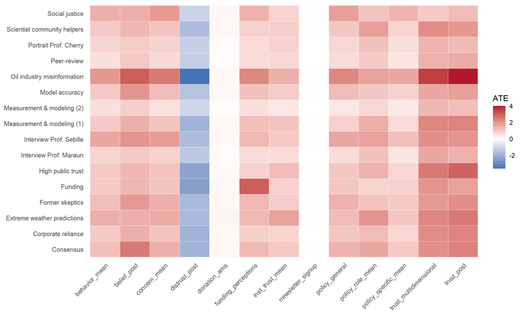

# 3. Forecast magnitude by outcome

This figure summarizes the distribution of absolute forecast magnitudes for each outcome and orders outcomes by their median magnitude. It describes the model’s scale of predictions; it is not evidence of empirical accuracy.

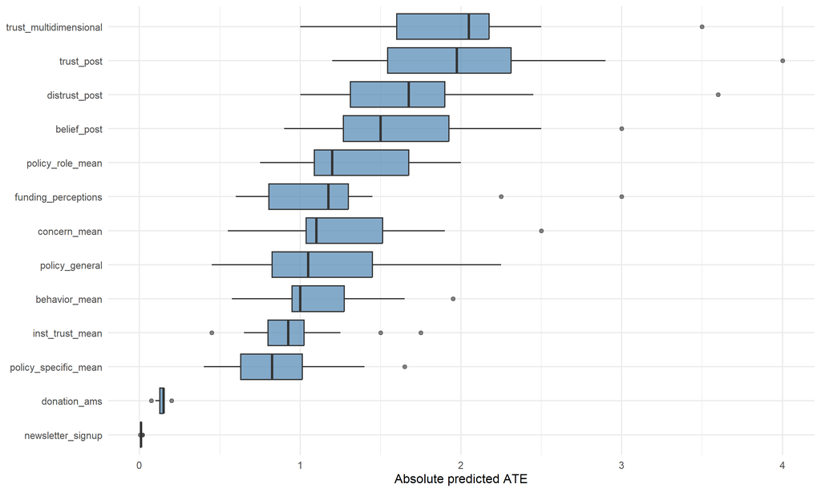

# 4. Prompt robustness

Each point compares the two prompt formulations for one intervention-outcome cell. Points close to the diagonal indicate that wording had little influence.

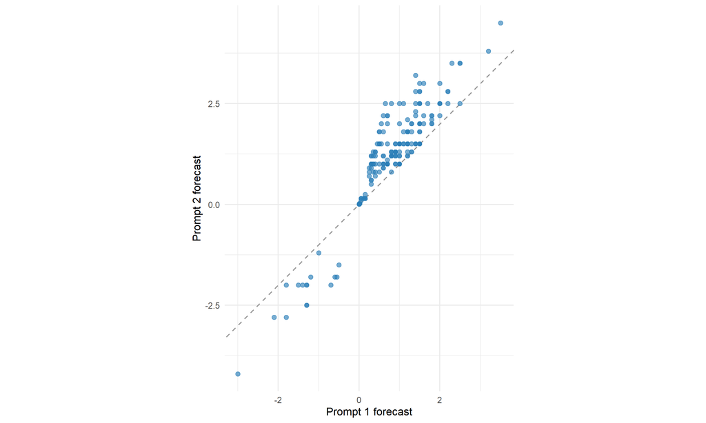

Pearson correlation across the 208 cells: **0.931**.

## Cells most sensitive to prompt wording

The table lists the ten cells with the largest prompt range after dividing by the width of that outcome’s native scale. This makes sensitivity more comparable across outcomes with different units.

| Intervention | Outcome | Minimum | Maximum | Range / scale width |
| --- | --- | --- | --- | --- |
| Peer-review | trust_post | 0.65 | 2.5 | 0.018 |
| Measurement & modeling (1) | trust_post | 1.40 | 3.2 | 0.018 |
| Interview Prof. Maraun | trust_multidimensional | 0.80 | 2.5 | 0.017 |
| Portrait Prof. Cherry | trust_multidimensional | 0.60 | 2.2 | 0.016 |
| Interview Prof. Maraun | trust_post | 0.70 | 2.2 | 0.015 |
| Interview Prof. Sebille | policy_role_mean | 1.00 | 2.5 | 0.015 |
| Measurement & modeling (1) | trust_multidimensional | 1.50 | 3.0 | 0.015 |
| Peer-review | trust_multidimensional | 0.70 | 2.2 | 0.015 |
| Portrait Prof. Cherry | trust_post | 0.55 | 2.0 | 0.014 |
| Corporate reliance | trust_post | 1.60 | 3.0 | 0.014 |

# 5. Interpretation and reproducibility

This single-model entry is useful as a controlled comparison with the primary three-family consensus: prompts and aggregation are held fixed while the model contributor changes. Model-agreement statistics are not applicable within this repository because it deliberately contains one submitted model.

The exact prompts, extracted benchmark inputs, archived structured responses, aggregation code, locked prediction file, and provenance are deposited here. Running scripts `03_build_submission.R` and `04_render_report.R` rebuilds the derived forecast and this report without making model calls. Script `02_run_forecasts.R` is retained for methodological transparency and defaults to preview mode with model calls disabled.